# R Notebook

## Import library

```r
library(tidyverse)
library(ggplot2)
library(gridExtra)
```

## Read file

```r
df = read.csv('../dataset/cleaned/cleaned_data_no_outlier_label.csv')

head(df, 5)
```

|  | assignment_gs_correct_count | assignment_gs_count | assignment_price | assignment_type | device_category | microtasks_count | os_family | project_has_audio | project_has_button | project_has_checkbox_input | project_has_externalHtml | project_has_fileAudio_input | project_has_fileImg_input | project_has_file_input | project_has_iframe | project_has_image | project_has_radio_input | project_has_sbs | project_has_select_input | project_has_sourcesRecorder_input | project_has_string_input | project_has_suggest_input | project_has_textarea_input | project_has_video | project_instruction_FK | project_instruction_language | project_instruction_len | project_instruction_wordCount | project_required_fields | … |
| --- | --- | --- | --- | --- | --- | --- | --- | --- | --- | --- | --- | --- | --- | --- | --- | --- | --- | --- | --- | --- | --- | --- | --- | --- | --- | --- | --- | --- | --- | --- |
| 1 | 3 | 3 | 0.03 | regular | PERSONAL_COMPUTER | 13 | WINDOWS | 4 | 0 | 0 | 0 | 0 | 0 | 0 | 0 | 0 | 2 | 0 | 0 | 0 | 0 | 0 | 0 | 0 | 9.686282 | ru | 579 | 67 | 2 | … |
| 2 | 0 | 0 | 0.01 | regular | PERSONAL_COMPUTER | 5 | WINDOWS | 0 | 0 | 0 | 0 | 0 | 0 | 0 | 0 | 1 | 3 | 0 | 0 | 0 | 0 | 0 | 0 | 0 | 46.743951 | ru | 2623 | 320 | 1 | … |
| 3 | 0 | 0 | 0.01 | regular | PERSONAL_COMPUTER | 1 | WINDOWS | 0 | 0 | 1 | 0 | 0 | 0 | 0 | 0 | 0 | 4 | 0 | 0 | 0 | 0 | 0 | 0 | 0 | 43.484352 | ru | 7118 | 720 | 2 | … |
| 4 | 0 | 0 | 0.03 | regular | PERSONAL_COMPUTER | 5 | WINDOWS | 0 | 0 | 0 | 0 | 0 | 0 | 0 | 0 | 0 | 0 | 0 | 0 | 0 | 1 | 0 | 0 | 0 | -12.335183 | ru | 783 | 92 | 0 | … |
| 5 | 1 | 2 | 0.01 | regular | PERSONAL_COMPUTER | 17 | WINDOWS | 0 | 0 | 0 | 0 | 0 | 0 | 0 | 0 | 1 | 3 | 0 | 0 | 0 | 0 | 0 | 0 | 0 | -21.670357 | ru | 490 | 46 | 0 | … |

```r
prepare.df.by.category = function(cat){

  data.by.cat = df %>% select('assignment_gs_correct_count',  'assignment_gs_count', 'assignment_price', 'microtasks_count', 'completion.time.in.minutes', cat)

  data.by.cat = data.by.cat %>%
  pivot_longer(cols=c('assignment_gs_correct_count',  'assignment_gs_count', 'assignment_price', 'microtasks_count'), names_to = 'parameter')

  return(data.by.cat)
}
```

```r
df2 = prepare.df.by.category('device_category')
```

```
Note: Using an external vector in selections is ambiguous.
ℹ Use `all_of(cat)` instead of `cat` to silence this message.
ℹ See <https://tidyselect.r-lib.org/reference/faq-external-vector.html>.
```

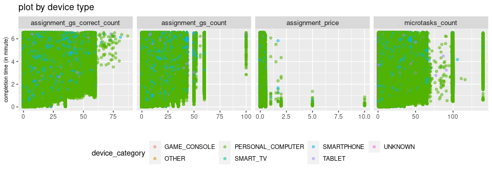

```r
plt = df2 %>% ggplot(aes(x=value, y=completion.time.in.minutes, color=device_category)) +
  geom_point(alpha = 0.5) +
  facet_wrap(vars(parameter), nrow=1, scales = "free_x") +
  xlab('') + ylab('completion time (in minute)') +
  ggtitle('plot by device type') +
  theme(
    strip.text = element_text(size = 10),
    axis.title.y = element_text(size = 8),
    legend.position = 'bottom'
  )

plt
```

The above graph shows scatter plot of `assignment_gs_correct_count`, `assignment_gs_count`, `assignment_price` and `microtasks_count` against completion time by device category.

The graph shows that regardless device category; `assignment_gs_correct_count`, `assignment_gs_count`, `assignment_price` and `microtasks_count` do not correlate with the completion time.

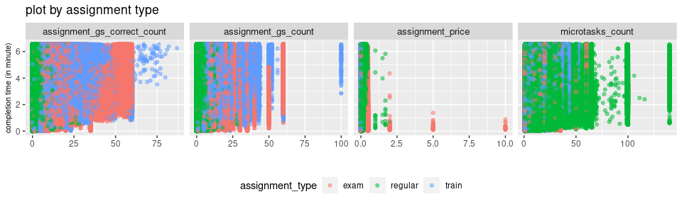

```r
df2 = prepare.df.by.category('assignment_type')

plt = df2 %>% ggplot(aes(x=value, y=completion.time.in.minutes, color=assignment_type)) +
  geom_point(alpha = 0.5) +
  facet_wrap(vars(parameter), nrow=1, scales = "free_x") +
  xlab('') + ylab('completion time (in minute)') +
  ggtitle('plot by assignment type') +
  theme(
    strip.text = element_text(size = 10),
    axis.title.y = element_text(size = 8),
    legend.position = 'bottom'
  )

plt
```

The above graph shows scatter plot of `assignment_gs_correct_count`, `assignment_gs_count`, `assignment_price` and `microtasks_count` against completion time by assignment type.

The graph shows that regardless assignment type; `assignment_gs_correct_count`, `assignment_gs_count` and `microtasks_count` do not correlate with the completion time. In contrast, for the *exam* assignment type, the higher `assignment_price` correlates with low completion time.

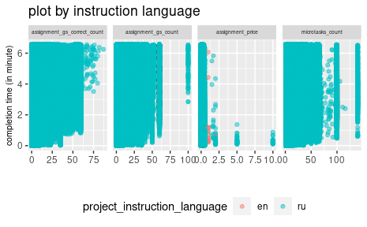

```r
df2 = prepare.df.by.category('project_instruction_language')

plt = df2 %>% ggplot(aes(x=value, y=completion.time.in.minutes, color=project_instruction_language)) +
  geom_point(alpha = 0.5) +
  facet_wrap(vars(parameter), nrow=1, scales = "free_x") +
  xlab('') + ylab('completion time (in minute)') +
  ggtitle('plot by instruction language') +
  theme(
    strip.text = element_text(size = 5),
    axis.title.y = element_text(size = 8),
    legend.position = 'bottom'
  )

plt
```

The above graph shows scatter plot of `assignment_gs_correct_count`, `assignment_gs_count`, `assignment_price` and `microtasks_count` against completion time by project instruction language.

The graph shows that regardless project instruction language; `assignment_gs_correct_count`, `assignment_gs_count` and `microtasks_count` do not correlate with the completion time. In contrast, for the *ru* project instruction, the higher `assignment_price` correlates with low completion time.

```r
prepare.df.by.category = function(cat){

  data.by.cat = df %>% select(project_has_audio, project_has_externalHtml, project_has_fileAudio_input, project_has_fileImg_input, project_has_file_input, project_has_iframe, project_has_sbs, project_has_select_input, project_has_sourcesRecorder_input, project_has_suggest_input, project_has_textarea_input, project_has_video, cat, completion.time.in.minutes)

  data.by.cat = data.by.cat %>%
  pivot_longer(cols=c('project_has_audio', 'project_has_externalHtml', 'project_has_fileAudio_input', 'project_has_fileImg_input', 'project_has_file_input', 'project_has_iframe', 'project_has_sbs', 'project_has_select_input', 'project_has_sourcesRecorder_input', 'project_has_suggest_input', 'project_has_textarea_input', 'project_has_video'), names_to = 'parameter')

  return(data.by.cat)
}
```

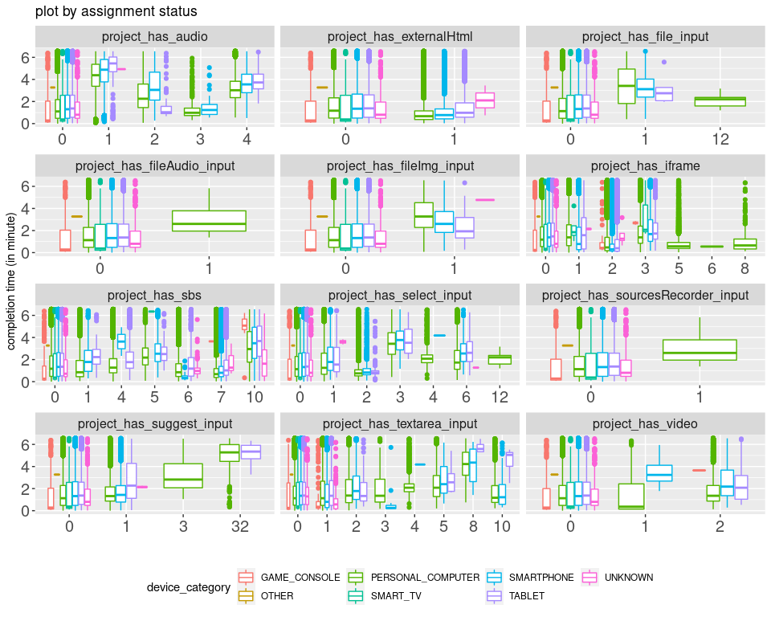

```r
df2 = prepare.df.by.category('device_category')

plt = df2 %>% ggplot(aes(x=factor(value), y=completion.time.in.minutes, color=device_category)) +
  geom_boxplot() +
  facet_wrap(vars(parameter), nrow=4, scales = "free_x") +
  xlab('') + ylab('completion time (in minute)') +
  ggtitle('plot by assignment status') +
  theme(
    strip.text = element_text(size = 12),
    axis.text.x = element_text(size=15),
    axis.text.y = element_text(size = 15),
    legend.position = 'bottom'
  )

plt
```

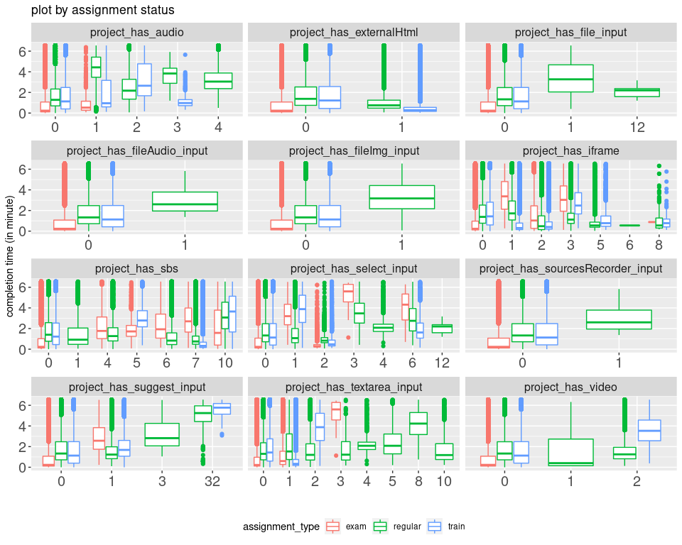

```r
df2 = prepare.df.by.category('assignment_type')

plt = df2 %>% ggplot(aes(x=factor(value), y=completion.time.in.minutes, color=assignment_type)) +
  geom_boxplot() +
  facet_wrap(vars(parameter), nrow=4, scales = "free_x") +
  xlab('') + ylab('completion time (in minute)') +
  ggtitle('plot by assignment status') +
  theme(
    strip.text = element_text(size = 12),
    axis.text.x = element_text(size=15),
    axis.text.y = element_text(size = 15),
    legend.position = 'bottom'
  )

plt
```

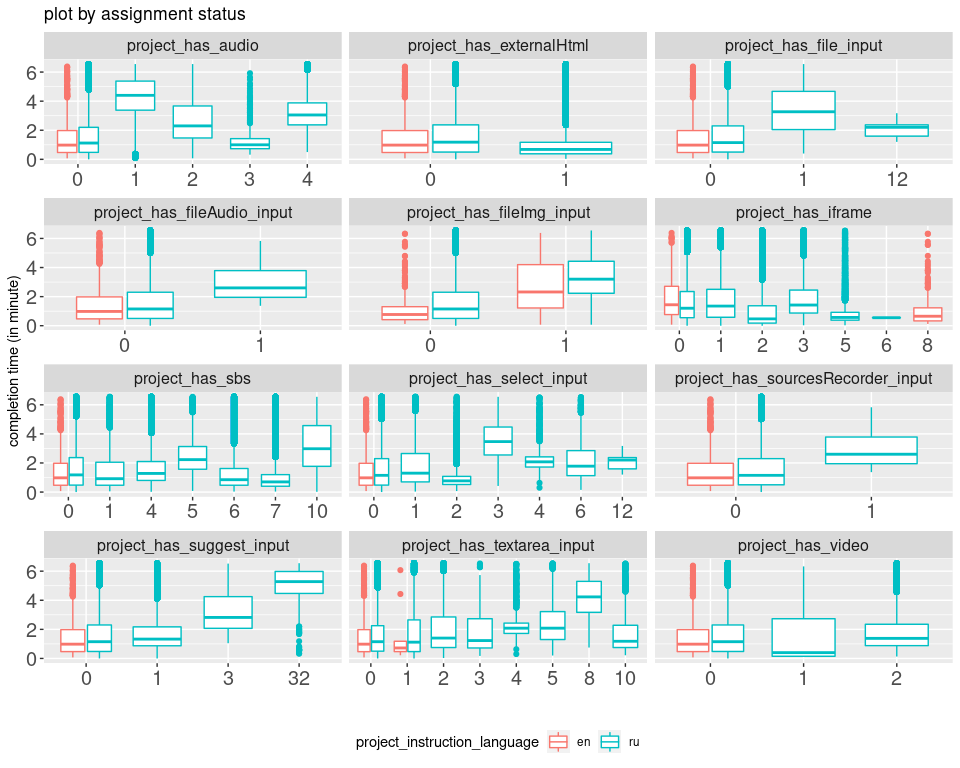

```r
df2 = prepare.df.by.category('project_instruction_language')

plt = df2 %>% ggplot(aes(x=factor(value), y=completion.time.in.minutes, color=project_instruction_language)) +
  geom_boxplot() +
  facet_wrap(vars(parameter), nrow=4, scales = "free_x") +
  xlab('') + ylab('completion time (in minute)') +
  ggtitle('plot by assignment status') +
  theme(
    strip.text = element_text(size = 12),
    axis.text.x = element_text(size=15),
    axis.text.y = element_text(size = 15),
    legend.position = 'bottom'
  )

plt
```

```r
prepare.df.by.category = function(cat){

  data.by.cat = df %>%
    select(project_instruction_FK, project_instruction_len, project_instruction_wordCount, project_required_fields, project_spec_length, completion.time.in.minutes, cat)

  data.by.cat = data.by.cat %>%
    pivot_longer(cols=c('project_instruction_FK', 'project_instruction_len', 'project_instruction_wordCount', 'project_required_fields', 'project_spec_length'), names_to = 'parameter')

  return(data.by.cat)
}
```

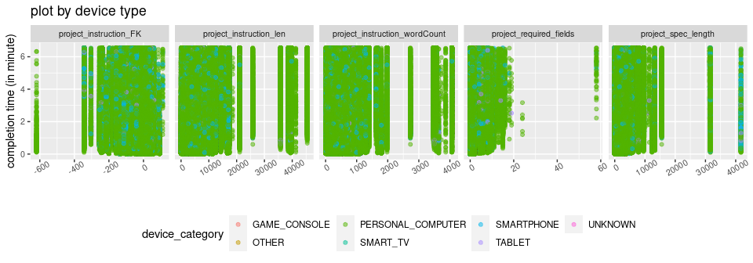

```r
df2 = prepare.df.by.category('device_category')

plt = df2 %>% ggplot(aes(x=value, y=completion.time.in.minutes, color=device_category)) +
  geom_point(alpha = 0.5) +
  facet_wrap(vars(parameter), nrow=1, scales = "free_x") +
  xlab('') + ylab('completion time (in minute)') +
  ggtitle('plot by device type') +
  theme(
    strip.text = element_text(size = 8),
    axis.text.x = element_text(size=8, angle = 30),
    axis.text.y = element_text(size = 8),
    legend.position = 'bottom'
  )

plt
```

The above graph shows scatter plot of `project_instruction_FK`, `project_instruction_len`, `project_instruction_wordCount`, `project_required_fields`, and `project_spec_length` against completion time by device category.

The graph shows that regardless device categories; `project_instruction_FK`, `project_instruction_len`, `project_instruction_wordCount`, `project_required_fields`, and `project_spec_length` do not correlate with the completion time.

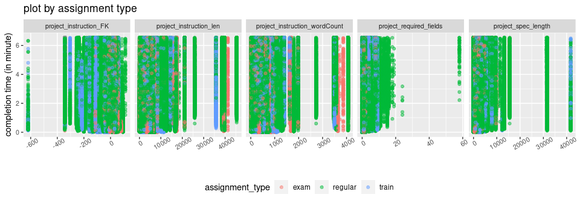

```r
df2 = prepare.df.by.category('assignment_type')

plt = df2 %>% ggplot(aes(x=value, y=completion.time.in.minutes, color=assignment_type)) +
  geom_point(alpha = 0.5) +
  facet_wrap(vars(parameter), nrow=1, scales = "free_x") +
  xlab('') + ylab('completion time (in minute)') +
  ggtitle('plot by assignment type') +
  theme(
    strip.text = element_text(size = 8),
    axis.text.x = element_text(size=8, angle = 30),
    axis.text.y = element_text(size = 8),
    legend.position = 'bottom'
  )

plt
```

The above graph shows scatter plot of `project_instruction_FK`, `project_instruction_len`, `project_instruction_wordCount`, `project_required_fields`, and `project_spec_length` against completion time by assignment type.

The graph shows that regardless assignment type; `project_instruction_FK`, `project_instruction_len`, `project_instruction_wordCount`, `project_required_fields`, and `project_spec_length` do not correlate with the completion time.

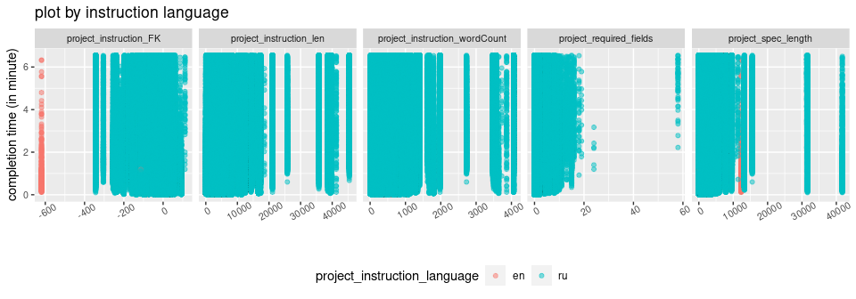

```r
df2 = prepare.df.by.category('project_instruction_language')

plt = df2 %>% ggplot(aes(x=value, y=completion.time.in.minutes, color=project_instruction_language)) +
  geom_point(alpha = 0.5) +
  facet_wrap(vars(parameter), nrow=1, scales = "free_x") +
  xlab('') + ylab('completion time (in minute)') +
  ggtitle('plot by instruction language') +
  theme(
    strip.text = element_text(size = 8),
    axis.text.x = element_text(size=8, angle = 30),
    axis.text.y = element_text(size = 8),
    legend.position = 'bottom'
  )

plt
```

The above graph shows scatter plot of `project_instruction_FK`, `project_instruction_len`, `project_instruction_wordCount`, `project_required_fields`, and `project_spec_length` against completion time by instruction language.

The graph shows that regardless instruction language; `project_instruction_FK`, `project_instruction_len`, `project_instruction_wordCount`, `project_required_fields`, and `project_spec_length` do not correlate with the completion time.

```r
prepare.df.by.category = function(cat){

  data.by.cat = df %>% select(project_has_button,  project_has_checkbox_input, project_has_image, project_has_radio_input, project_has_string_input, completion.time.in.minutes, cat)

  data.by.cat = data.by.cat %>%
    pivot_longer(cols=c('project_has_button',  'project_has_checkbox_input', 'project_has_image', 'project_has_radio_input', 'project_has_string_input'), names_to = 'parameter')

  return(data.by.cat)
}
```

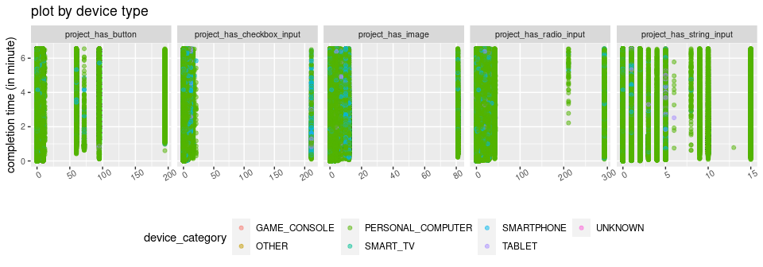

```r
df2 = prepare.df.by.category('device_category')

plt = df2 %>% ggplot(aes(x=value, y=completion.time.in.minutes, color=device_category)) +
  geom_point(alpha = 0.5) +
  facet_wrap(vars(parameter), nrow=1, scales = "free_x") +
  xlab('') + ylab('completion time (in minute)') +
  ggtitle('plot by device type') +
  theme(
    strip.text = element_text(size = 8),
    axis.text.x = element_text(size=8, angle = 30),
    axis.text.y = element_text(size = 8),
    legend.position = 'bottom'
  )

plt
```

The above graph shows scatter plot of `project_has_button`, `project_has_checkbox_input`, `project_has_image`, `project_has_radio_input`, and `project_has_string_input` against completion time by device category.

The graph shows that regardless device categories; `project_has_button`, `project_has_checkbox_input`, `project_has_image`, `project_has_radio_input`, and `project_has_string_input` do not correlate with the completion time.

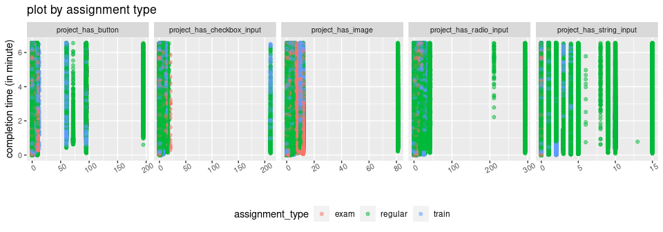

```r
df2 = prepare.df.by.category('assignment_type')

plt = df2 %>% ggplot(aes(x=value, y=completion.time.in.minutes, color=assignment_type)) +
  geom_point(alpha = 0.5) +
  facet_wrap(vars(parameter), nrow=1, scales = "free_x") +
  xlab('') + ylab('completion time (in minute)') +
  ggtitle('plot by assignment type') +
  theme(
    strip.text = element_text(size = 8),
    axis.text.x = element_text(size=8, angle = 30),
    axis.text.y = element_text(size = 8),
    legend.position = 'bottom'
  )

plt
```

The above graph shows scatter plot of `project_has_button`, `project_has_checkbox_input`, `project_has_image`, `project_has_radio_input`, and `project_has_string_input` against completion time by assignment type.

The graph shows that regardless assignment types; `project_has_button`, `project_has_checkbox_input`, `project_has_image`, `project_has_radio_input`, and `project_has_string_input` do not correlate with the completion time.

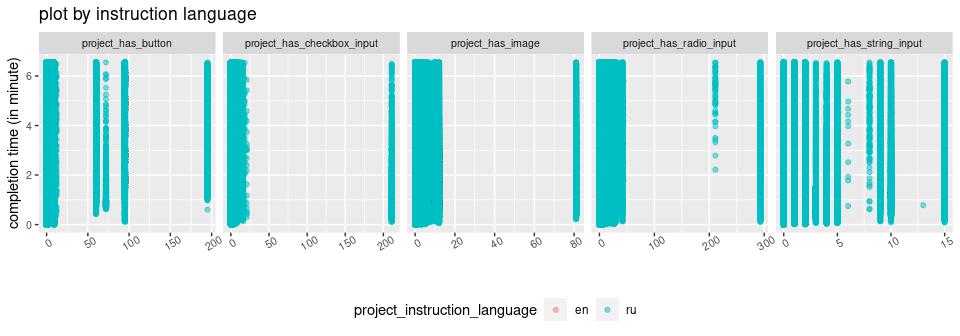

```r
df2 = prepare.df.by.category('project_instruction_language')

plt = df2 %>% ggplot(aes(x=value, y=completion.time.in.minutes, color=project_instruction_language)) +
  geom_point(alpha = 0.5) +
  facet_wrap(vars(parameter), nrow=1, scales = "free_x") +
  xlab('') + ylab('completion time (in minute)') +
  ggtitle('plot by instruction language') +
  theme(
    strip.text = element_text(size = 8),
    axis.text.x = element_text(size=8, angle = 30),
    axis.text.y = element_text(size = 8),
    legend.position = 'bottom'
  )

plt
```

The above graph shows scatter plot of `project_has_button`, `project_has_checkbox_input`, `project_has_image`, `project_has_radio_input`, and `project_has_string_input` against completion time by instruction language.

The graph shows that regardless instruction language; `project_has_button`, `project_has_checkbox_input`, `project_has_image`, `project_has_radio_input`, and `project_has_string_input` do not correlate with the completion time.